# Titanic Survival Probability

Max Raven

2023-04-20

# Introduction

Link to Titanic Survival Dataset

Have you ever wondered what the difference in survival is between man and women, or what was the survival rate if you happened to be on there depending on age, passenger class, or sex on the titanic. The data I decided to work with was TitanicSurvival dataset provided by R studio. This data was compiled by Thomas Cason.

[figure not shown]

# Questions:

1. The total number of survivors per passenger class?
2. The total number of survivors per sex?
3. The total number of survivors per age?
4. Now lets classify the individuals by the type of age group and see how it is different.
5. The total number of survivors per sex and passenger class?
6. The total number of survivors per age and passenger class?
7. The total number of survivors per age and sex?
8. The total numbers of survivors per female sex,age, and passenger class?
9. The total numbers of survivors per male sex,age, and passenger class?

# Packages Used

```r
#using this for data manipulation
library(dplyr)
#using this to tidy up the data
library(tidyverse)
#using for visual data
library(ggplot2)
```

# Unfiltered Data

```r
Titanic_Survival <- read.csv("TitanicSurvival.csv")
glimpse(Titanic_Survival)
```

```
## Rows: 1,309
## Columns: 5
## $ X              <chr> "Allen, Miss. Elisabeth Walton", "Allison, Master. Huds…
## $ survived       <chr> "yes", "yes", "no", "no", "no", "yes", "yes", "no", "ye…
## $ sex            <chr> "female", "male", "female", "male", "female", "male", "…
## $ age            <dbl> 29.0000, 0.9167, 2.0000, 30.0000, 25.0000, 48.0000, 63.…
## $ passengerClass <chr> "1st", "1st", "1st", "1st", "1st", "1st", "1st", "1st",…
```

# Key Terms for Unfiltered Data & Filtered Data

- X: Name of passenger
- survived: If that passenger survived or not
- sex: Gender of passenger
- age: numerical age of passenger
- passengerClass: The type of class the passenger was in
- Category: Age group classified

# Key Values and Calculations:

# 1. The total number of survivers per passenger class?

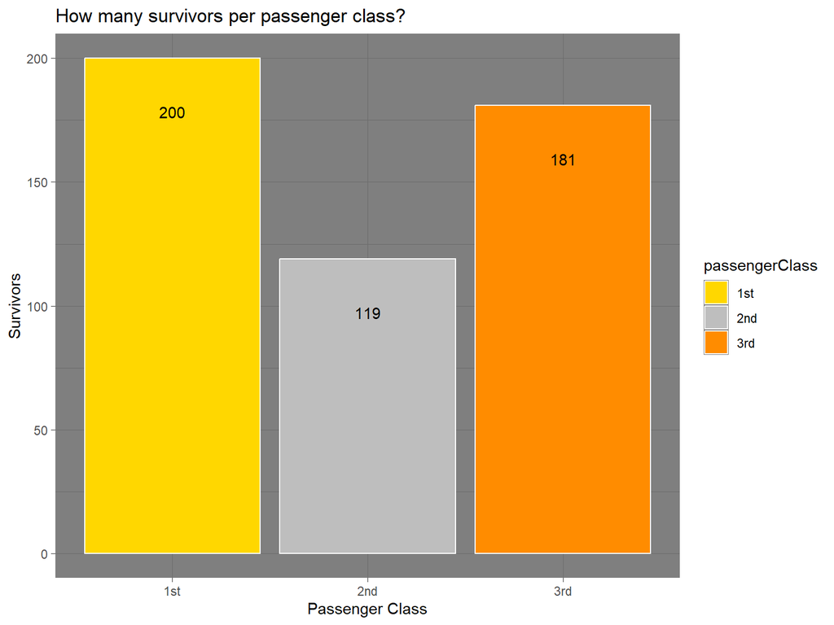

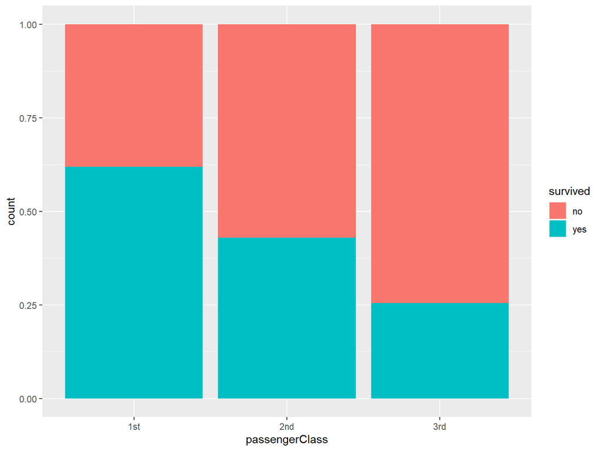

# 2. The total number of survivors per sex?

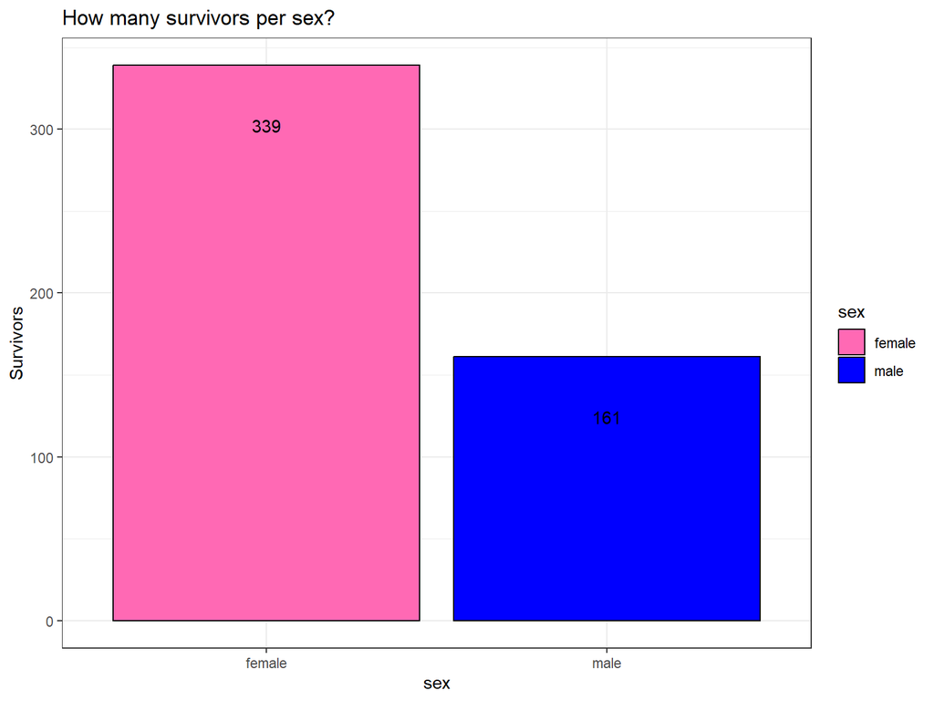

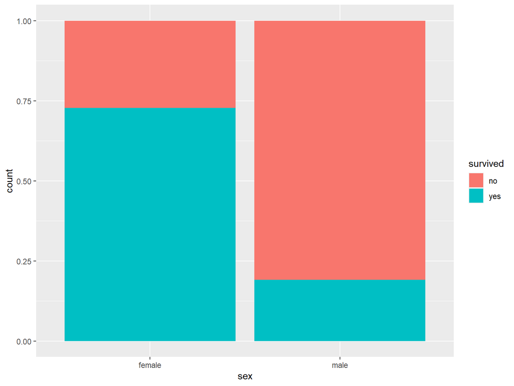

# 3. The total number of survivers per age

[figure not shown]

# 4. Now lets classify the individuals by the type of age group and see how it is different

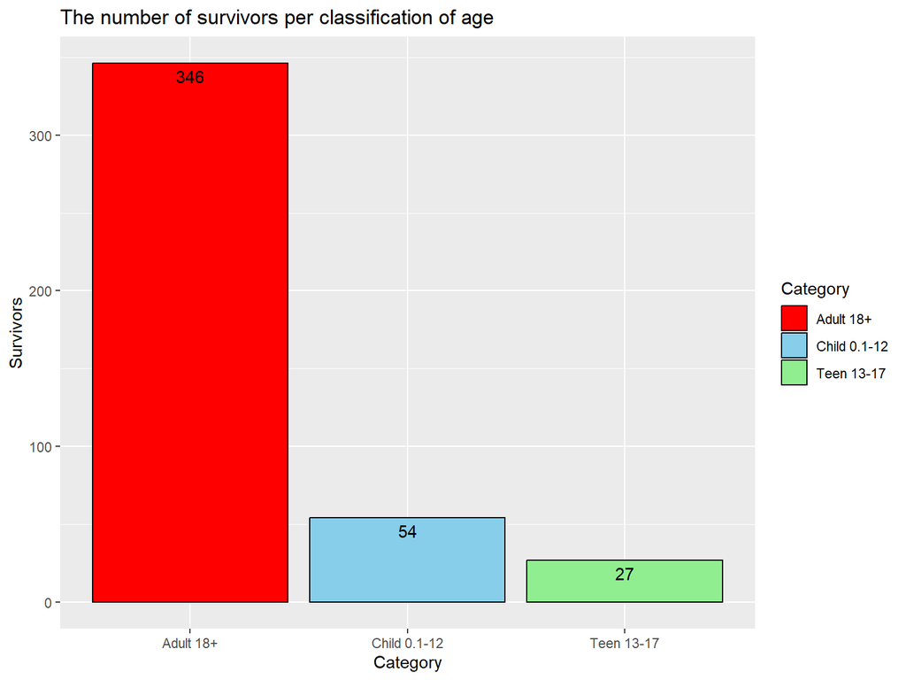

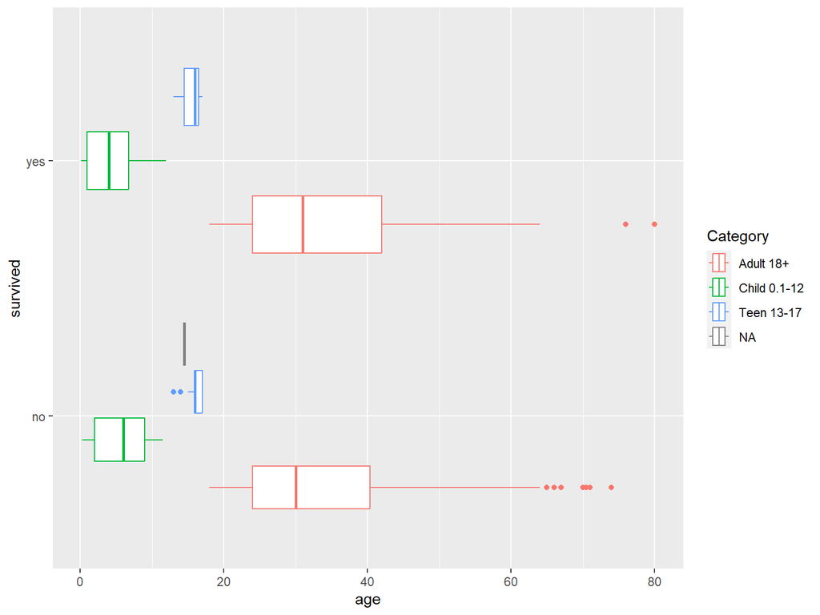

# 5. The total numbers of survivors per sex and age

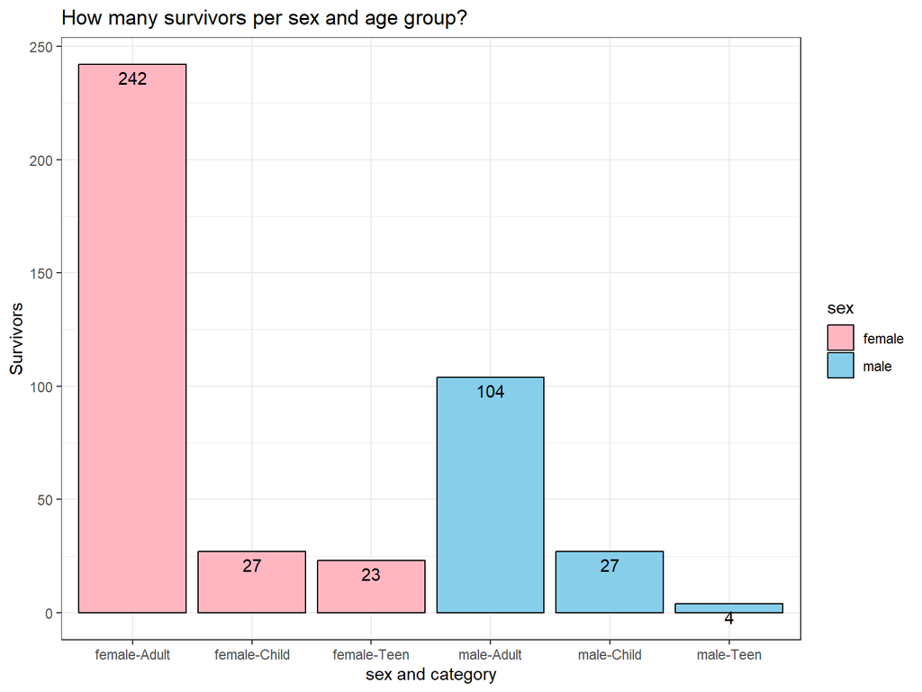

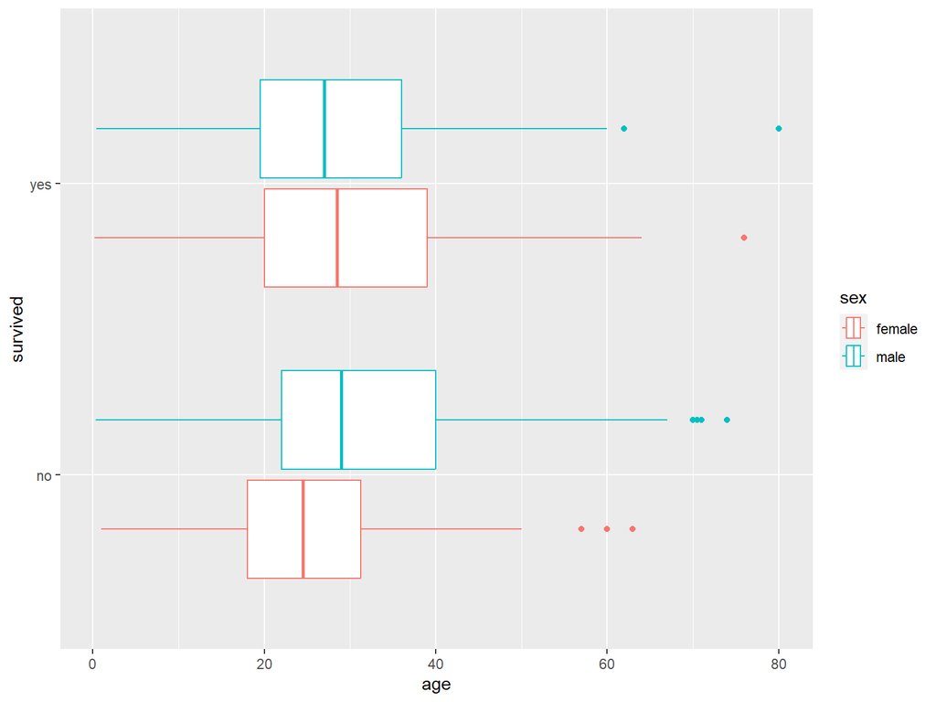

# 6. The total number of survivers per sex and passenger class

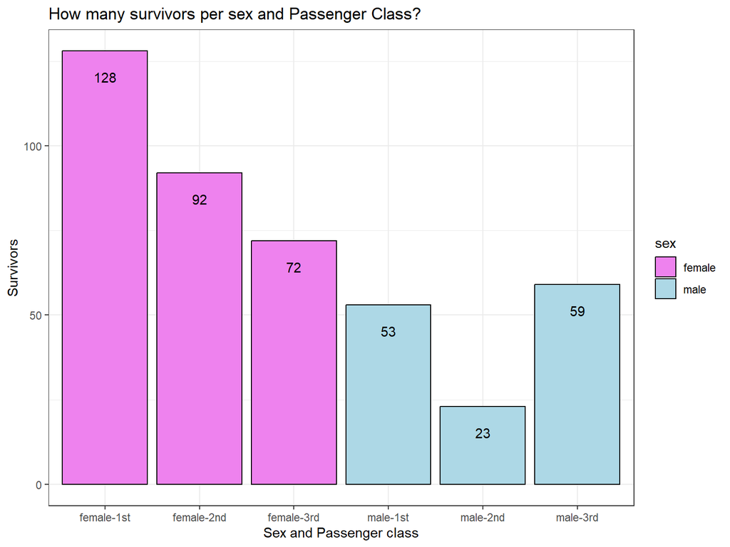

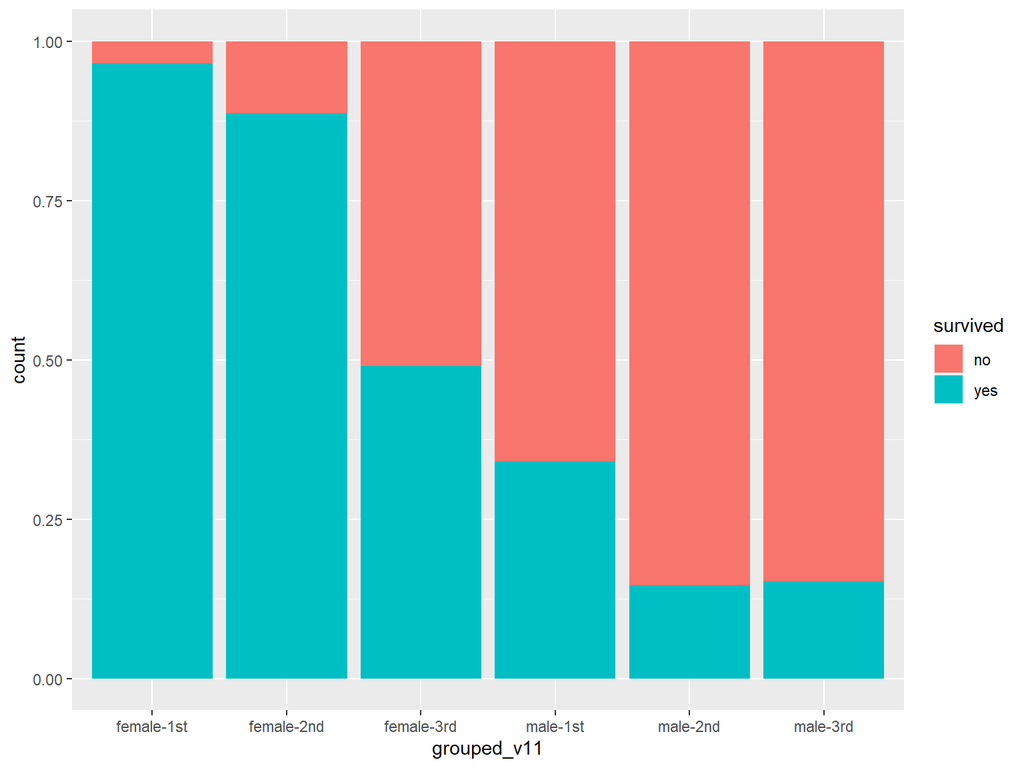

# 7. The total number of survivers per age and passenger class

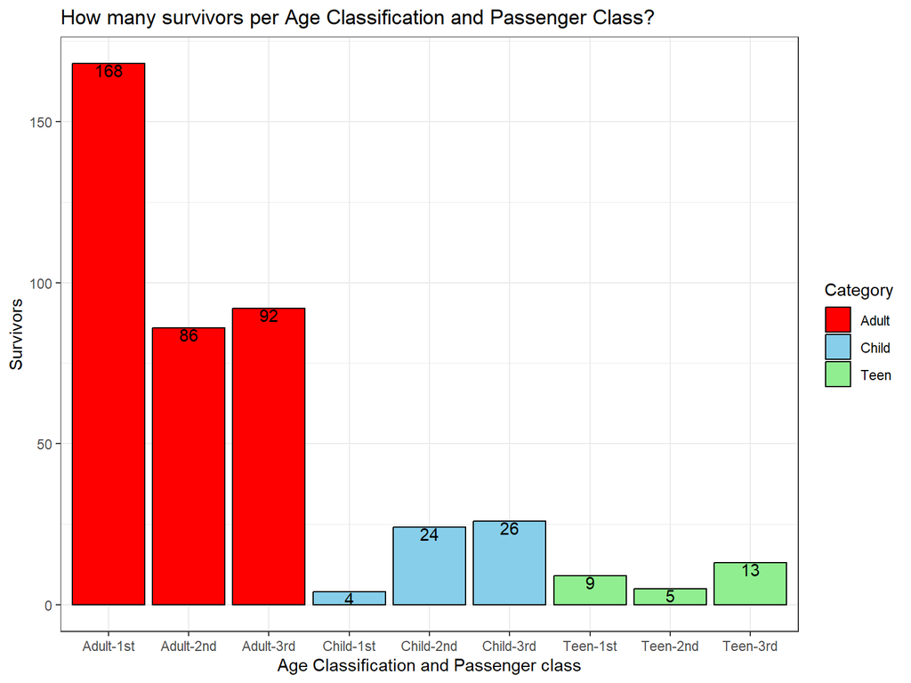

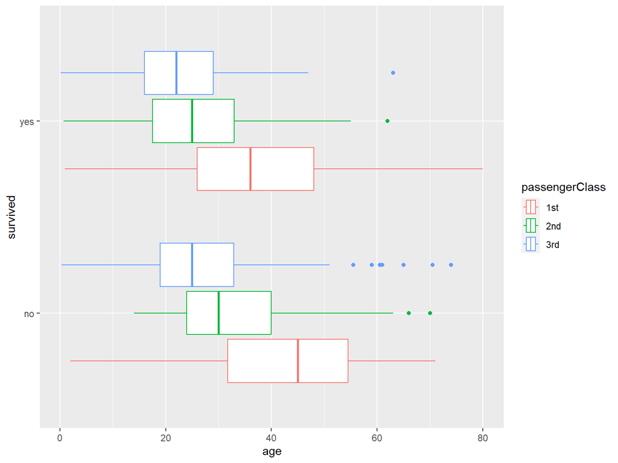

# 8. The total numbers of survivers per male sex,age, and passenger class

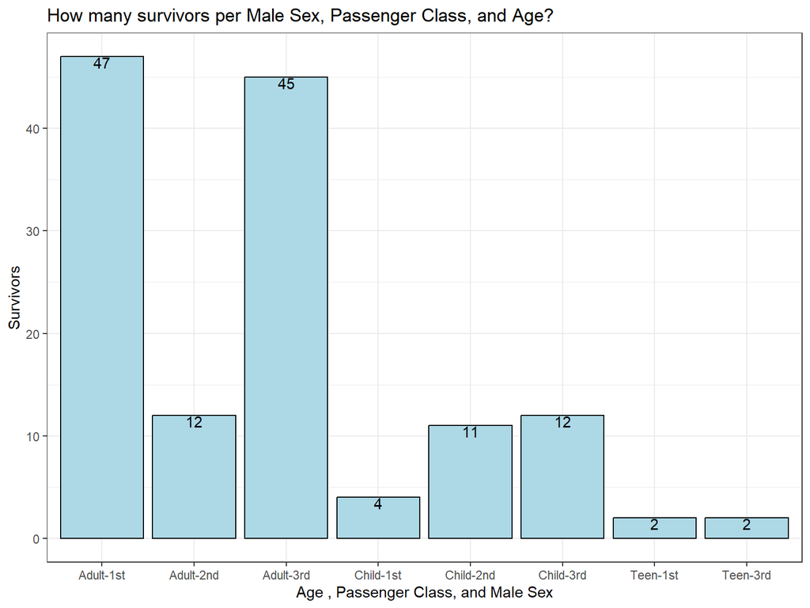

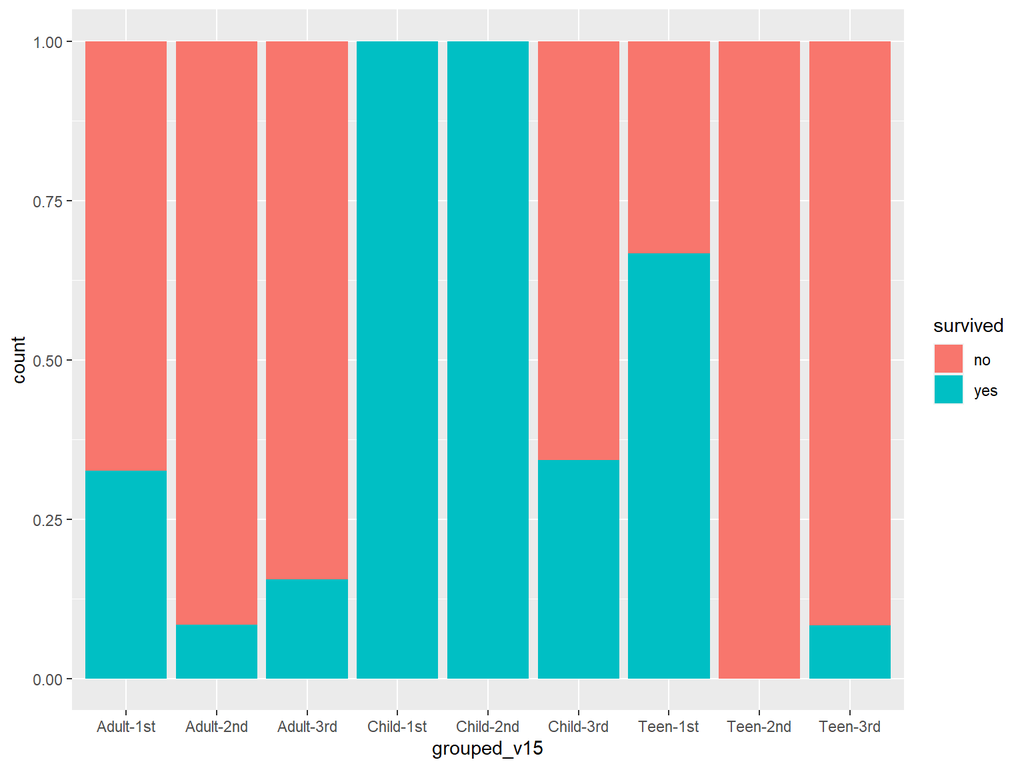

# 9. The total numbers of survivers per female sex,age, and passenger class

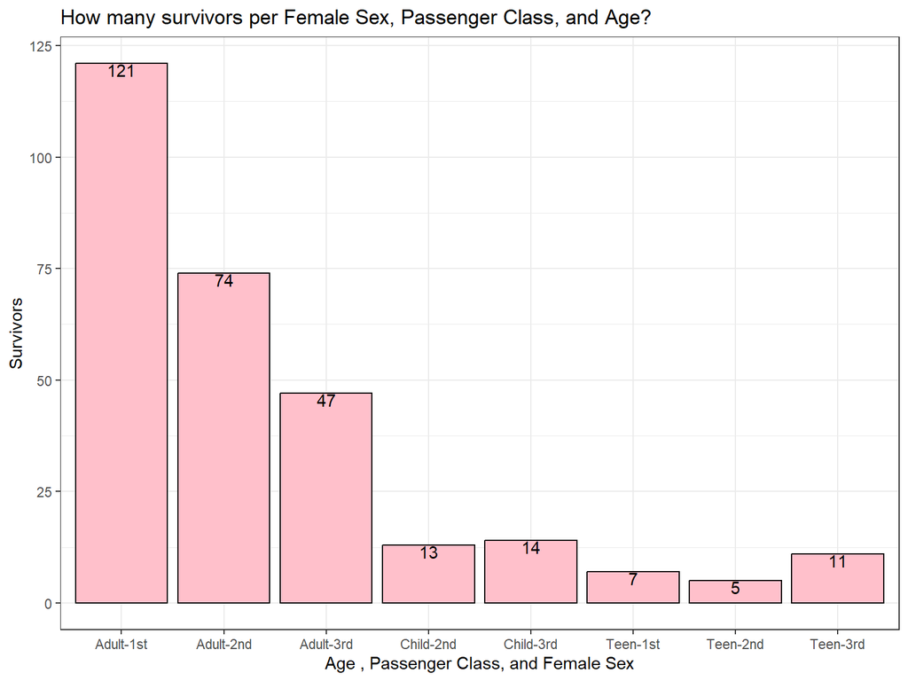

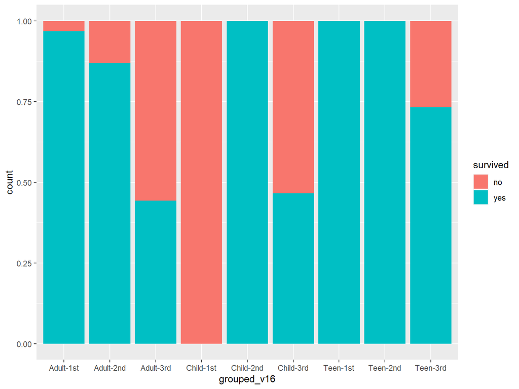

# Summary

If you happened to be on the titanic, you better hope you were a female